# Open data survey

Tomas Klingström

2024-10-23

# About this report

This report is designed with two purposes in mind.

If read directly without opening the code chunks the report provides a comparative analysis of the State of Open Data survey 2021 published by Digital Science (https://doi.org/10.6084/m9.figshare.17081231) and a community specific survey to survey the State of Open Data and attitudes towards FAIR data policies conducted by the Pigweb consortium. The Pigweb study is built on the template provided by the State of Open Data Survey to maximize the comparability between the pig research community participating in Pigweb and the much larger study conducted by Digital Science and Springer Nature. It does however also contain some specific questions regarding experiences with infrastructure and services supporting FAIR data.

Opening the code chunks provided in the document or downloading the github repository (https://github.com/SGBC/survey) enables researchers to copy the report and reuse it as a template for their own comparative studies. The document is divided into a number of code chunks with data pruning and functions at the top followed by the report with the code chunks generating data interspersed between them. The code in each chunk evaluating questions can be broken down into four parts:

1. Parsing the response tables from each questionnaire.
2. Recoding the responses from the two different surveys into the same format using functions in the file plotting_functions.R
3. Plotting response data with functions in the file plotting_functions.R.
4. Testing for statistic significance and other numeric analysis if applicable.

The code is release under a GNU General Public License v3.0 and is written to be as easily accessible as possible for students, researchers or other people who need to quickly parse and analyse a large study.

```r
sod21 <- read.csv2("sod21.csv")
pigw21 <- read.csv("pigw21.csv", sep=";") #Note: The original pigw21 file has been altered so that the column showing completion of survey is now last.
names(sod21) <- gsub(" ", "", names(sod21))

sod21collist <- data.frame(colnames(sod21)) #List of all columns with index
pig21collist <- data.frame(colnames(pigw21)) #List of all columns with index


#In the pigweb survey the last question was for respondents to provide their e-mail address and organisation for follow up questions. This is personal information which is not to be shared outside the limited timesframe of the project.
#pigw21 = pigw21[1:(length(pigw21)-6)]



#Apart from directly identifiable information it is important to ensure that combinations of information cannot be used to trace the respondents. In this case we have #therefore decided to separate the respondent data from the rest of the survey and scramble the rows. Thereby combinations such as year of first publication and major #source of finance cannot be used to identify respondents by a process of elimination. Note: This code was not used as a

#This snippet take the first 9 columns of the pigw21 dataset, put them in a separate dataframe and shuffles each column before putting it back together.
#pigrespondents = dplyr::select(pigw21, 1:9)
#pigw21 = dplyr::select(pigw21, !1:9)
#pigrespondents = as.data.frame(lapply(pigrespondents, sample))
#pigw21 = cbind(pigrespondents, pigw21)
#write_xlsx(pigw21, path = "pigw21s.xlsx")
#The shuffled file is the file shared in the supplementary data and loaded at the start of this chunk.

#A problem with the surveys is that we do not have a way of knowing if an answer is a 0 or empty due to conscious lack of response by the respondent or due to the respondent not finishing the survey.

#This sets the Data Frames to start at the first question. Each code chunk take the columns corresponding to a question and pass it to the pile when done.
sod21Pile = dplyr::select(sod21, 1:9)

pigw21Pile = dplyr::select(pigw21,1:3)
```

## Data in the survey

1. Likert scale questions, usually with a five point scale going from “I strongly disagree” to “I strongly agree”. These are reported using an empirical cumulative distribution function with one line each for the State of Open Data and the Pigweb survey. Hypothesis testing with calculation of p-values is done with a Kolmogorov-Smirnov test with the alternate hypothesis being that respondents are drawn from two populations with different preferences
2. Single choice questions, selecting between different options the respondent select the most fitting one. A frequency bar plot with the different alternatives is used to visualize these responses.
3. Multiple choice questions, respondents may select multiple answers to the question.A frequency bar plot with the different alternatives is used to visualize these responses with the frequency being the number of respondents who selected an answer divided by the number of respondents.

## About the respondents

The first three questions of the surveys were about the first year of publication, primary area of research interest and international collaboration.

```r
#Each chunk take a number of columns from the sod21 and pigw21 dataframes and put them in a separate dataframe for processing which is numbered sequentially.
#The sod21collist and pigw21collist dataframes provides index numbers for each dataframe to help selecting the right row.
sod21Q1 = as.data.frame(dplyr::select(sod21,10))
sod21Pile = cbind(sod21Pile, sod21Q1)
colnames(sod21Q1) = c('Q1')

pigw21Q1 = as.data.frame(dplyr::select(pigw21, 4))
pigw21Pile = cbind(pigw21Pile, pigw21Q1)

#Setting columnnames and storing the question
colnames(sod21Q1) = c('Q1')
colnames(pigw21Q1) = c('Q1')
Q1 = 'When was the last occasion that you published or submitted a manuscript to a journal?'

#unique(sod21Q2) #unique() is used to identify the unique answers of the question. It is commented out here to make the Notebook tidier.

#Setting the answer options to Question 1.
Q1_levels = c("Within the last year", "1-2 years ago",
              "3-5 years ago", "More than 5 years ago",
              "I have never submitted a manuscript to a journal")

Q1_data = format_question_likert(sod21Q1$Q1,
                                 pigw21Q1$Q1,
                                 Q1_levels)
```

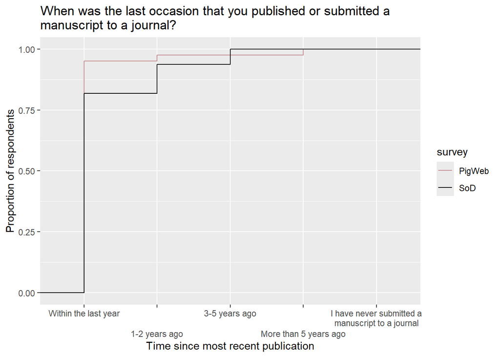

```r
plot_likert(Q1_data,
            Q1_levels,
            Q1,
            "Time since most recent publication")
```

```r
ks.test(Q1_data$response[Q1_data$survey == "SoD"],
        Q1_data$response[Q1_data$survey == "PigWeb"],
        ifresult = FALSE) #Kolmogorov-Smirnov test for Q1
```

```
##
##  Asymptotic two-sample Kolmogorov-Smirnov test
##
## data:  Q1_data$response[Q1_data$survey == "SoD"] and Q1_data$response[Q1_data$survey == "PigWeb"]
## D = 0.13, p-value = 0.4
## alternative hypothesis: two-sided
```

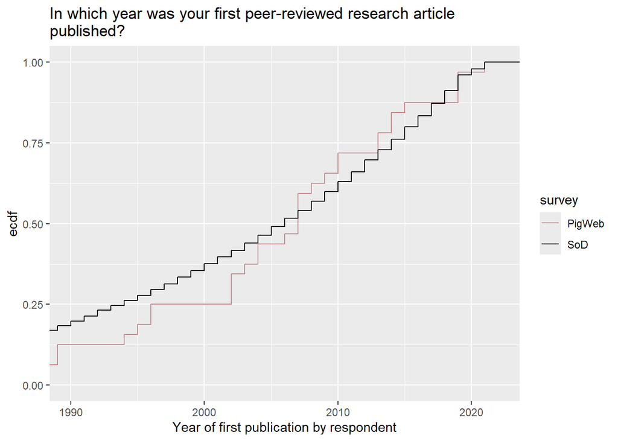

Figure 2

```r
#Each chunk take a number of columns from the sod21 and pigw21 dataframes and put them in a separate dataframe for processing which is numbered sequentially.
#The sod21collist and pigw21collist dataframes provides index numbers for each dataframe to help selecting the right row.
sod21Q2 = as.data.frame(dplyr::select(sod21, 11))
sod21Pile = cbind(sod21Pile, sod21Q2) #Add it to the frame for questions already done.


pigw21Q2 = as.data.frame(dplyr::select(pigw21, 5))
pigw21Pile = cbind(pigw21Pile, pigw21Q2) #Add it to the frame for questions already done.


Q2 = 'In which year was your first peer-reviewed research article published?'
colnames(sod21Q2) = c('Q2')
colnames(pigw21Q2) = c('Q2')

Q2_data = format_question_numeric(sod21Q2$Q2,
                                  pigw21Q2$Q2)

plot_numeric(Q2_data,
             Q2,
             "Year of first publication by respondent") +
  coord_cartesian(xlim = c(1990, 2022))
```

```r
Q2KS = ks.test(Q2_data$response[Q2_data$survey == "SoD"],
        Q2_data$response[Q2_data$survey == "PigWeb"],
        ifresult = FALSE) #Kolmogorov-Smirnov test for Q2
```

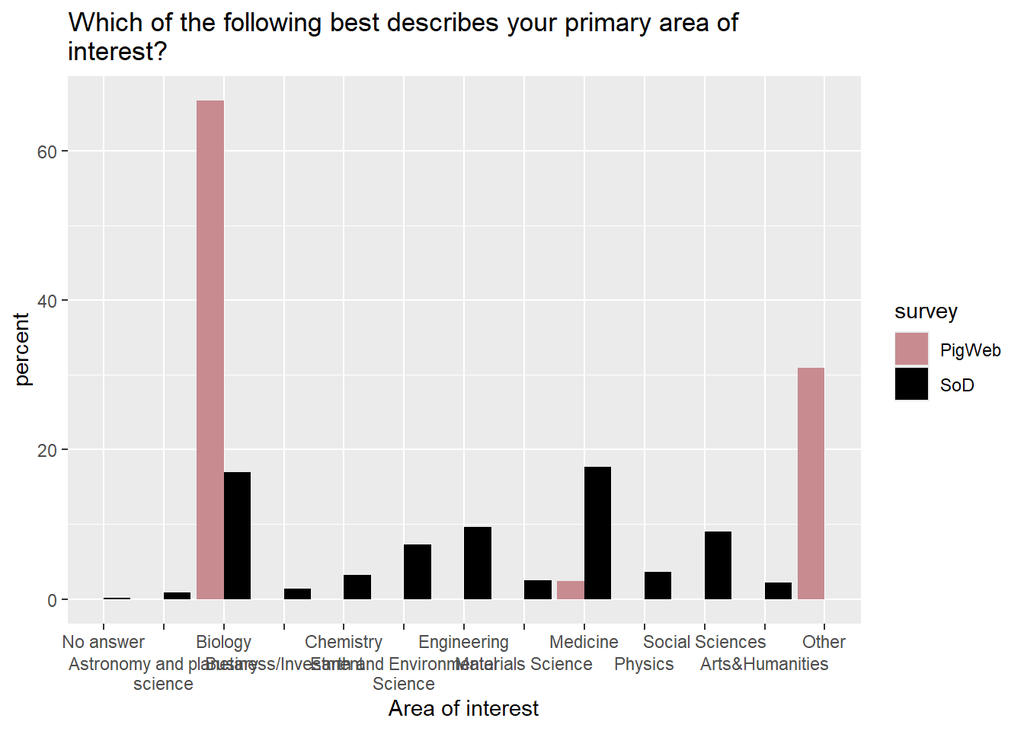

Figure 3

```r
#This is a single choice question with an "other".
sod21Q3 = as.data.frame(dplyr::select(sod21, 12))
sod21Pile = cbind(sod21Pile, sod21Q3)

pigw21Q3 = as.data.frame(dplyr::select(pigw21, 6))
pigw21Pile = cbind(pigw21Pile, pigw21Q3)

Q3 = 'Which of the following best describes your primary area of interest?'
colnames(sod21Q3) = c('Q3')
colnames(pigw21Q3) = c('Q3')

## Fix the formatting of "Arts & Humanities"
sod21Q3$Q3 = sub(sod21Q3$Q3,
                 pattern = "Arts &amp; Humanities|Arts & Humanities",
                 replacement = "Arts&Humanities")

Q3_levels = c("Astronomy and planetary science",
              "Biology",
              "Business/Investment",
              "Chemistry",
              "Earth and Environmental Science",
              "Engineering",
              "Materials Science",
              "Medicine",
              "Physics",
              "Social Sciences",
              "Arts&Humanities",
              "Other")

Q3_data = format_question_single_choice(sod21Q3$Q3,
                                        pigw21Q3$Q3,
                                        Q3_levels)

plot_single_choice(Q3_data,
                   Q3_levels,
                   Q3,
                   "Area of interest")
```

```r
## Others responses
unique(pigw21[,6])

sod21Q3other = as.data.frame(dplyr::select(sod21, 1))
sod21Pile = cbind(sod21Pile, sod21Q3other)


pigw21Q3other = as.data.frame(dplyr::select(pigw21, 1))
pigw21Pile = cbind(pigw21Pile, pigw21Q3other)
```

Researchers participating in the PigWeb survey are to a higher degree involved in collaborations than respondents in the State of Open Data survey which is consistent with survey participants being recruited from an EU project on building infrastructure for experimental research for sustainable pig production.

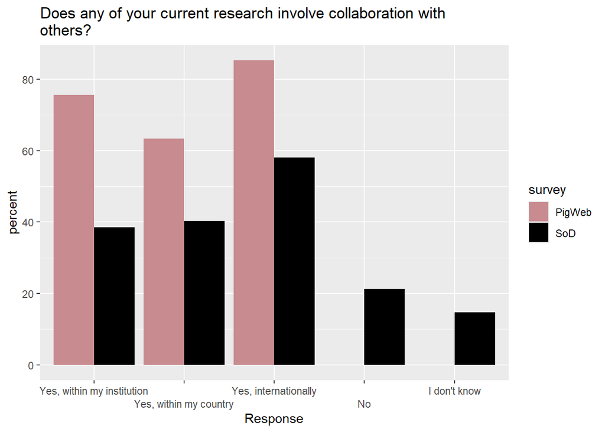

Figure 4

```r
#This code chunk uses the multiple choice functions.
Q4_levels = c("Yes, within my institution",
              "Yes, within my country",
              "Yes, internationally",
              "No",
              "I don't know")
n_columns = length(Q4_levels)

sod21Q4 = as.data.frame(dplyr::select(sod21, (14:sum(14,n_columns,-1))))
sod21Pile = cbind(sod21Pile, sod21Q4)

pigw21Q4 = as.data.frame(dplyr::select(pigw21, (9:sum(9,n_columns-1))))
pigw21Pile = cbind(pigw21Pile, pigw21Q4)

Q4 = 'Does any of your current research involve collaboration with others?'

Q4_data = format_question_multiple_choice(sod21Q4,
                                          pigw21Q4,
                                          Q4_levels)

plot_multiple_choice(Q4_data,
                     Q4_levels,
                     Q4,
                     "Response")
```

## Views on open access and open sharing of data or other results results.

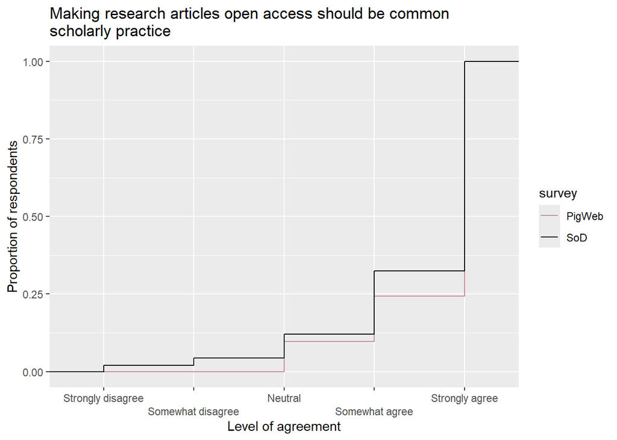

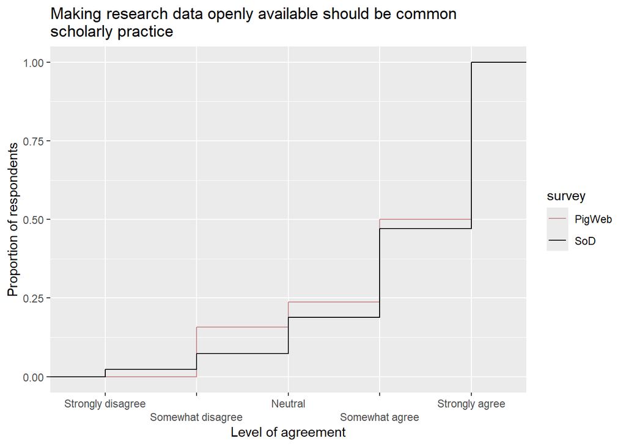

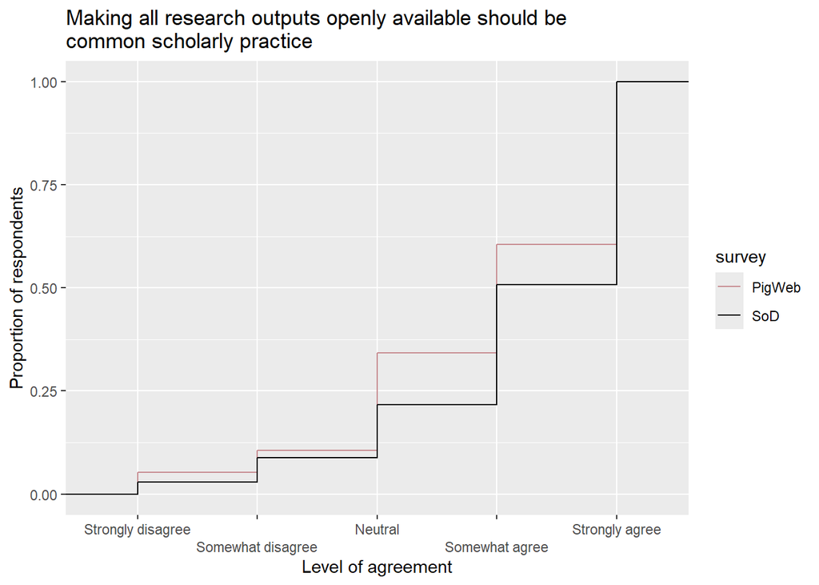

Figure 5-7

```r
#Question 5, 6 and 7 are similar and are therefore displayed together. Kolmogorov smirnov test output from the distributions are hidden in the automated output.

#Data to be analysed in the chunk is copied to the Q5 data frame and the pile before being removed from the data frame. The process is repeated for each question in it's respective chunk
#Note rerunning the below lines will move the currently first column in sod21 and pigw21, so running the code immediately below a second times means that the wrong question will be processed.
sod21Q5 = as.data.frame(dplyr::select(sod21,19))
sod21Pile = cbind(sod21Pile, sod21Q5)
colnames(sod21Q5) = c('Q5')

pigw21Q5 = as.data.frame(dplyr::select(pigw21, 14))
pigw21Pile = cbind(pigw21Pile, pigw21Q5)


#Setting columnnames and storing the question
colnames(sod21Q5) = c('Q5')
colnames(pigw21Q5) = c('Q5')
Q5 = 'Making research articles open access should be common scholarly practice'

#unique(sod21Q2) #unique() is used to identify the unique answers of the question. It is commented out here to make the Notebook tidier.

#Setting the answer options to Question 6.
Q5_levels = c("Strongly disagree", "Somewhat disagree",
              "Neutral", "Somewhat agree",
              "Strongly agree")
#The Pigweb scale puts strong agreement as 1 and strong disagreement as 5, this needs to be reversed for the question.
pigw21Q5$Q5 = reverseCode(pigw21Q5$Q5)

Q5_data = format_question_likert(sod21Q5$Q5,
                                 pigw21Q5$Q5,
                                 Q5_levels)

plot_likert(Q5_data,
            Q5_levels,
            Q5,
            "Level of agreement")

#Data to be analysed in the chunk is copied to the Q6 data frame and the pile before being removed from the data frame. The process is repeated for each question in it's respective chunk
#Note rerunning the below lines will move the currently first column in sod21 and pigw21, so running the code immediately below a second times means that the wrong question will be processed.
sod21Q6 = as.data.frame(dplyr::select(sod21,20))
sod21Pile = cbind(sod21Pile, sod21Q6)
colnames(sod21Q6) = c('Q6')

pigw21Q6 = as.data.frame(dplyr::select(pigw21, 15))
pigw21Pile = cbind(pigw21Pile, pigw21Q6)

#Setting columnnames and storing the question
colnames(sod21Q6) = c('Q6')
colnames(pigw21Q6) = c('Q6')
Q6 = 'Making research data openly available should be common scholarly practice'

#unique(sod21Q2) #unique() is used to identify the unique answers of the question. It is commented out here to make the Notebook tidier.

#Setting the answer options to Question 7.
Q6_levels = c("Strongly disagree", "Somewhat disagree",
              "Neutral", "Somewhat agree",
              "Strongly agree")
#The Pigweb scale puts strong agreement as 1 and strong disagreement as 5, this needs to be reversed for the question.
pigw21Q6$Q6 = reverseCode(pigw21Q6$Q6)

Q6_data = format_question_likert(sod21Q6$Q6,
                                 pigw21Q6$Q6,
                                 Q6_levels)

plot_likert(Q6_data,
            Q6_levels,
            Q6,
            "Level of agreement")

#Question 8
sod21Q7 = as.data.frame(dplyr::select(sod21,21))
sod21Pile = cbind(sod21Pile, sod21Q7)
colnames(sod21Q7) = c('Q7')

pigw21Q7 = as.data.frame(dplyr::select(pigw21, 16))
pigw21Pile = cbind(pigw21Pile, pigw21Q7)

#Setting columnnames and storing the question
colnames(sod21Q7) = c('Q7')
colnames(pigw21Q7) = c('Q7')
Q7 = 'Making all research outputs openly available should be common scholarly practice'

#unique(sod21Q2) #unique() is used to identify the unique answers of the question. It is commented out here to make the Notebook tidier.

#Setting the answer options to Question 8.
Q7_levels = c("Strongly disagree", "Somewhat disagree",
              "Neutral", "Somewhat agree",
              "Strongly agree")
#The Pigweb scale puts strong agreement as 1 and strong disagreement as 5, this needs to be reversed for the question.
pigw21Q7$Q7 = reverseCode(pigw21Q7$Q7)

Q7_data = format_question_likert(sod21Q7$Q7,
                                 pigw21Q7$Q7,
                                 Q7_levels)

plot_likert(Q7_data,
            Q7_levels,
            Q7,
            "Level of agreement")

#This section test for if there is statistically significant difference in the respondent groups¨
#with the null hypothesis that the two populations are the same.

SvPQ5 = ks.test(Q5_data$response[Q5_data$survey == "SoD"],
        Q5_data$response[Q5_data$survey == "PigWeb"],
        ifresult = FALSE) #Kolmogorov-Smirnov test for Q5

SvPQ6 = ks.test(Q6_data$response[Q6_data$survey == "SoD"],
        Q6_data$response[Q6_data$survey == "PigWeb"],
        ifresult = FALSE) #Kolmogorov-Smirnov test for Q6

SvPQ7 = ks.test(Q7_data$response[Q7_data$survey == "SoD"],
        Q7_data$response[Q7_data$survey == "PigWeb"],
        ifresult = FALSE) #Kolmogorov-Smirnov test for Q7


PQ5vPQ7= ks.test(Q5_data$response[Q5_data$survey == "PigWeb"],
        Q7_data$response[Q7_data$survey == "PigWeb"],
        ifresult = FALSE) #Kolmogorov-Smirnov test for Q5 vs Q7

SQ5vSQ7= ks.test(Q5_data$response[Q5_data$survey == "SoD"],
        Q7_data$response[Q7_data$survey == "SoD"],
        ifresult = FALSE) #Kolmogorov-Smirnov test for Q5 vs Q7
```

Comparing the responses for each question there are no statistically significant differences between the populations(p = 0.957, 0.9502, and 0.593 respectively). In both questionnaires respondents are however less likely to agree with the statement “Making all research outputs openly available should be common scholarly practice” than to the statement “Making research articles open access should be common scholarly practice” (p = 0 the State of Open Data survey and 0.0015 for the PigWeb survey). The difference is markedly larger in the PigWeb survey as measured by the maximum geometric distance D between the two graphs (D = 0.3614 for Pigweb and D = 0.1834 for State of Open Data). We hypothesise that despite similar levels of support for open access publishing a higher proportion of the PigWeb participants are engaged in research together with commercial stakeholders which do not permit the open sharing of all data from studies made due to trade secrets and other immaterial property rights which will be followed up during a second phase of the PigWeb project with qualitative interviews. Researchers in PigWeb are also to a large degree of the existence of FAIR data as a concept but unfamiliar with applying it in practice.

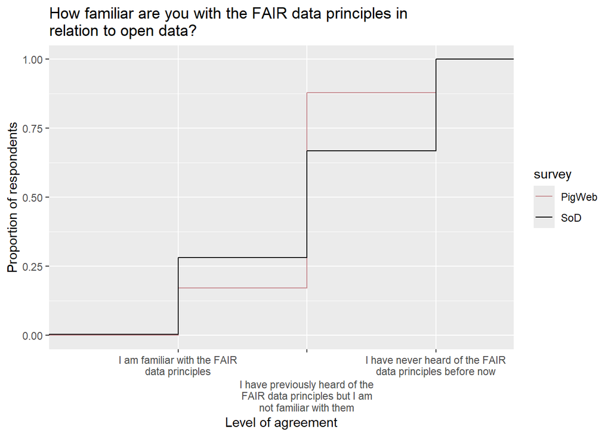

Figure 8

```r
#Data to be analysed in the chunk is copied to the Q8 data frame and the pile before being removed from the data frame. The process is repeated for each question in it's respective chunk
#Note rerunning the below lines will move the currently first column in sod21 and pigw21, so running the code immediately below a second times means that the wrong question will be processed.
sod21Q8 = as.data.frame(dplyr::select(sod21,22))
sod21Pile = cbind(sod21Pile, sod21Q8)
colnames(sod21Q8) = c('Q8')

pigw21Q8 = as.data.frame(dplyr::select(pigw21, 17))
pigw21Pile = cbind(pigw21Pile, pigw21Q8)

#Setting columnnames and storing the question
colnames(sod21Q8) = c('Q8')
colnames(pigw21Q8) = c('Q8')
Q8 = 'How familiar are you with the FAIR data principles in relation to open data?'

#unique(sod21Q2) #unique() is used to identify the unique answers of the question. It is commented out here to make the Notebook tidier.

#Setting the answer options to Question 9.
Q8_levels = c("I am familiar with the FAIR data principles", "I have previously heard of the FAIR data principles but I am not familiar with them", "I have never heard of the FAIR data principles before now")
#Reordering function for questions where this is necessary.
#pigw21Q8$Q8 = reverseCode(pigw21Q8$Q8)

Q8_data = format_question_likert(sod21Q8$Q8,
                                 pigw21Q8$Q8,
                                 Q8_levels)

plot_likert(Q8_data,
            Q8_levels,
            Q8,
            "Level of agreement")



#This section test for if there is statistically significant difference in the respondent groups¨
#with the null hyptohesis that the two populations are the same.

SvPQ8 = ks.test(Q8_data$response[Q8_data$survey == "SoD"],
        Q8_data$response[Q8_data$survey == "PigWeb"],
        ifresult = FALSE) #Kolmogorov-Smirnov test for Q8
```

## Implementation of FAIR data sharing in PigWeb

These questions are unique to the PigWeb survey and included as the European Commission policy is to promote and support FAIR data. In many cases FAIR data is also open data but in many sectors collaborations, immaterial rights and other requirements limit the ability to openly share all data and the PigWeb survey therefore include current work on FAIR data as supported by the EU commission and many national research organisations as well as the questions used in the State of Open Data survey.

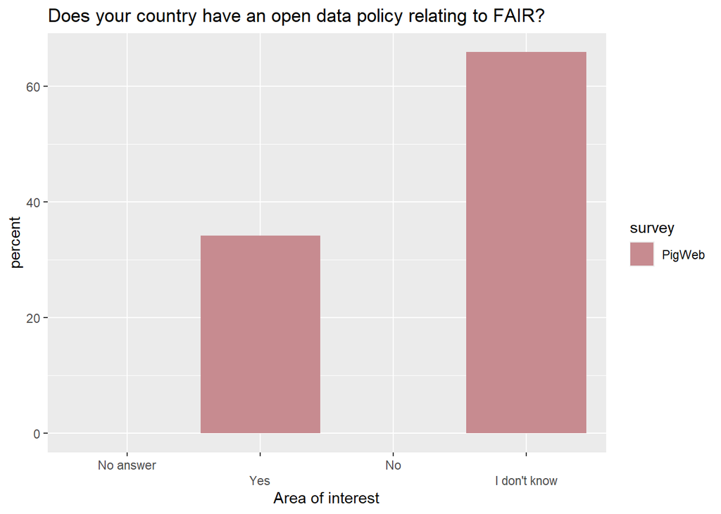

Figure 9

```r
#This is a single choice question without an "other" with responses only in the PigWeb survey.

pigw21Q9 = as.data.frame(dplyr::select(pigw21, 18))
pigw21Pile = cbind(pigw21Pile, pigw21Q9)

Q9 = 'Does your country have an open data policy relating to FAIR?'
colnames(pigw21Q9) = c('Q9')

Q9_levels = c("Yes", "No", "I don't know")

#The function is given a 0 instead of the column expected form the SoD survey as there is no question in it.
Q9_data = format_question_single_choice_pigweb(pigw21Q9$Q9,
                                        Q9_levels)

plot_single_choice(Q9_data,
                   Q9_levels,
                   Q9,
                   "Area of interest")
```

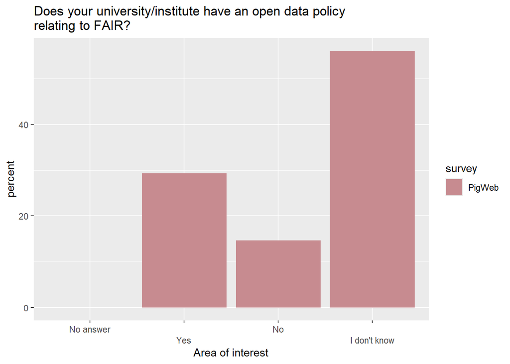

Figure 10

```r
#This is a single choice question without an "other" with responses only in the PigWeb survey.

pigw21Q10 = as.data.frame(dplyr::select(pigw21, 19))
pigw21Pile = cbind(pigw21Pile, pigw21Q10)


Q10 = 'Does your university/institute have an open data policy relating to FAIR?'
colnames(pigw21Q10) = c('Q10')

Q10_levels = c("Yes", "No", "I don't know")

#The function is given a 0 instead of the column expected form the SoD survey as there is no question in it.
Q10_data = format_question_single_choice_pigweb(pigw21Q10$Q10,
                                        Q10_levels)

plot_single_choice(Q10_data,
                   Q10_levels,
                   Q10,
                   "Area of interest")
```

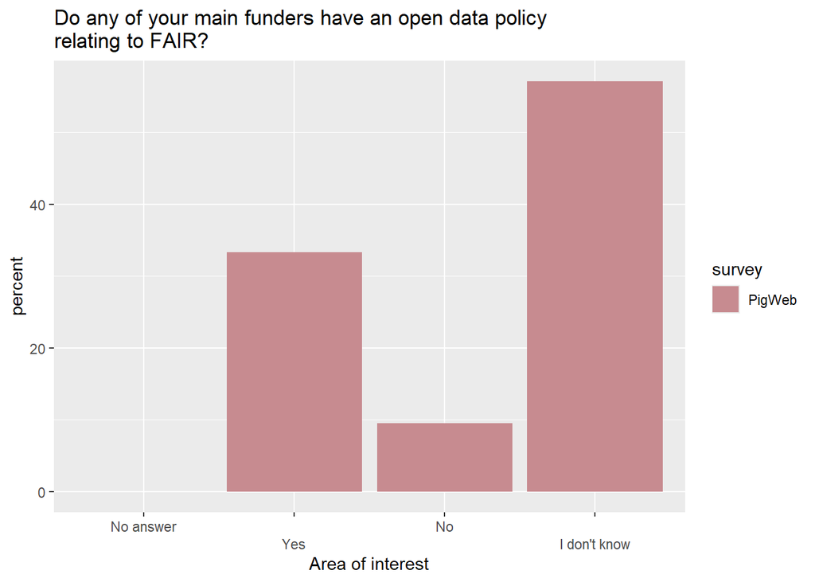

Figure 11

```r
#This is a single choice question without an "other" with responses only in the PigWeb survey.

pigw21Q11 = as.data.frame(dplyr::select(pigw21, 20))
pigw21Pile = cbind(pigw21Pile, pigw21Q11)


Q11 = 'Do any of your main funders have an open data policy relating to FAIR?'
colnames(pigw21Q11) = c('Q11')

Q11_levels = c("Yes", "No", "I don't know")

#The function is given a 0 instead of the column expected form the SoD survey as there is no question in it.
Q11_data = format_question_single_choice_pigweb(pigw21Q11$Q11,
                                        Q11_levels)

plot_single_choice(Q11_data,
                   Q11_levels,
                   Q11,
                   "Area of interest")
```

## Data curation and management

```
##                                                                  Q12
## 1                                No, its not important with our data
## 3                                         No, other (please specify)
## 4     No, we don't have the resource to do this but we would like to
## 14                                           Yes, all data collected
## 31                                Yes, but only data shared publicly
## 41               Yes, but only data shared with colleagues or beyond
## 52                                   Yes, some of the data collected
## 4342                                                  Yes, some data
## 4347                                                   Yes, all data
## 4354                            No, it's not important with our data
## 9149                                     No , other (please specify)
## 14630    No, we don't have the resource to do this but would like to
## 14657                                                              0
## 14661                                    No, other (please specify):
## 15805
```

```
##                                                                  Q12
## 1                                No, its not important with our data
## 3                                         No, other (please specify)
## 4     No, we don't have the resource to do this but we would like to
## 14                                           Yes, all data collected
## 31                                Yes, but only data shared publicly
## 41               Yes, but only data shared with colleagues or beyond
## 52                                   Yes, some of the data collected
## 14657                                                              0
## 15805
```

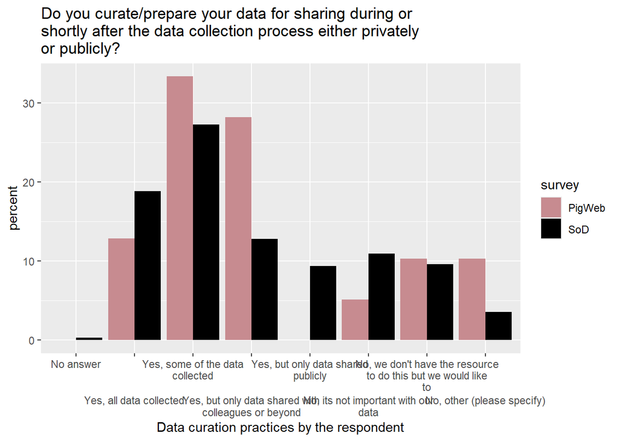

Figure 12

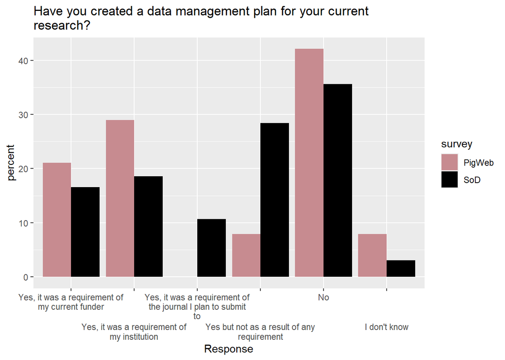

Figure 13

```r
#This code chunk uses the multiple choice functions.
Q13_levels = c("Yes, it was a requirement of my current funder",
              "Yes, it was a requirement of my institution",
              "Yes, it was a requirement of the journal I plan to submit to",
              "Yes but not as a result of any requirement",
              "No",
              "I don't know")
n_columns = length(Q13_levels)


sod21Q13 = as.data.frame(dplyr::select(sod21, (25:sum(25,n_columns,-1))))
sod21Pile = cbind(sod21Pile, sod21Q13)

pigw21Q13 = as.data.frame(dplyr::select(pigw21, (23:sum(23,n_columns,-1))))
pigw21Pile = cbind(pigw21Pile, pigw21Q13)

Q13 = 'Have you created a data management plan for your current research?'

Q13_data = format_question_multiple_choice(sod21Q13,
                                          pigw21Q13,
                                          Q13_levels)

plot_multiple_choice(Q13_data,
                     Q13_levels,
                     Q13,
                     "Response")
```

Only a single researcher report sharing data to be FAIR and open but in total half the researchers report the data as being at least somewhat open and FAIR-compliant.

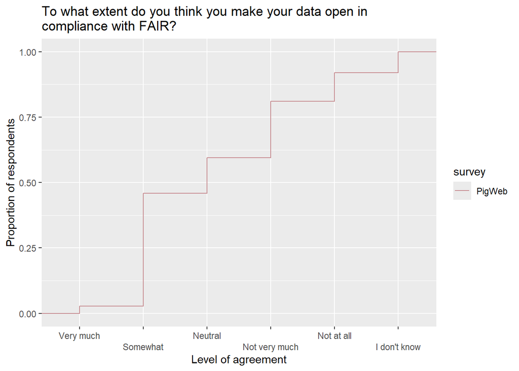

Figure 14

```r
#This question is only in the Pigweb study Data to be analysed in the chunk is copied to the Q14 data frame and the pile before being removed from the data frame. The process is repeated for each question in it's respective chunk
#Note rerunning the below lines will move the currently first column in pigw21, so running the code immediately below a second times means that the wrong question will be processed.


pigw21Q14 = as.data.frame(dplyr::select(pigw21, 29))
pigw21Pile = cbind(pigw21Pile, pigw21Q14)

#Setting columnnames and storing the question
colnames(pigw21Q14) = c('Q14')
Q14 = 'To what extent do you think you make your data open in compliance with FAIR?'

#unique(sod21Q2) #unique() is used to identify the unique answers of the question. It is commented out here to make the Notebook tidier.

#Setting the answer options to Question 9.
Q14_levels = c("Very much", "Somewhat", "Neutral", "Not very much", "Not at all", "I don't know")
#Reordering function for questions where this is necessary.
#pigw21Q14$Q14 = reverseCode(pigw21Q14$Q14)

Q14_data = format_question_likert_pigweb(pigw21Q14$Q14,
                                 Q14_levels)

plot_likert(Q14_data,
            Q14_levels,
            Q14,
            "Level of agreement")
```

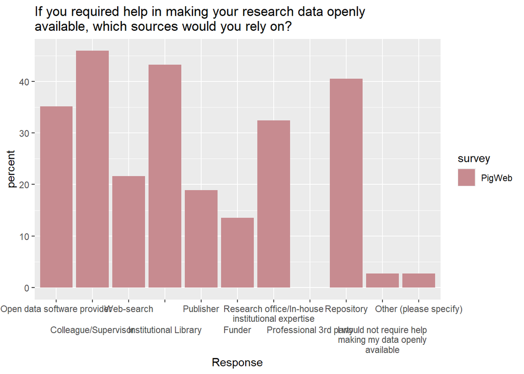

Figure 15

```r
#This code chunk uses the multiple choice functions.
Q15_levels = c("Open data software provider",
              "Colleague/Supervisor",
              "Web-search",
              "Institutional Library",
              "Publisher",
              "Funder",
              "Research office/In-house institutional expertise",
              "Professional 3rd party",
              "Repository",
              "I would not require help making my data openly available",
              "Other (please specify)"
              )
n_columns = length(Q15_levels)

pigw21Q15 = as.data.frame(dplyr::select(pigw21, (30:sum(30,n_columns,-1))))
pigw21Pile = cbind(pigw21Pile, pigw21Q15)

Q15 = 'If you required help in making your research data openly available, which sources would you rely on?'

Q15_data = format_question_multiple_choice_pigweb(pigw21Q15,
                                          Q15_levels)

plot_multiple_choice(Q15_data,
                     Q15_levels,
                     Q15,
                     "Response")
```

#Question 16

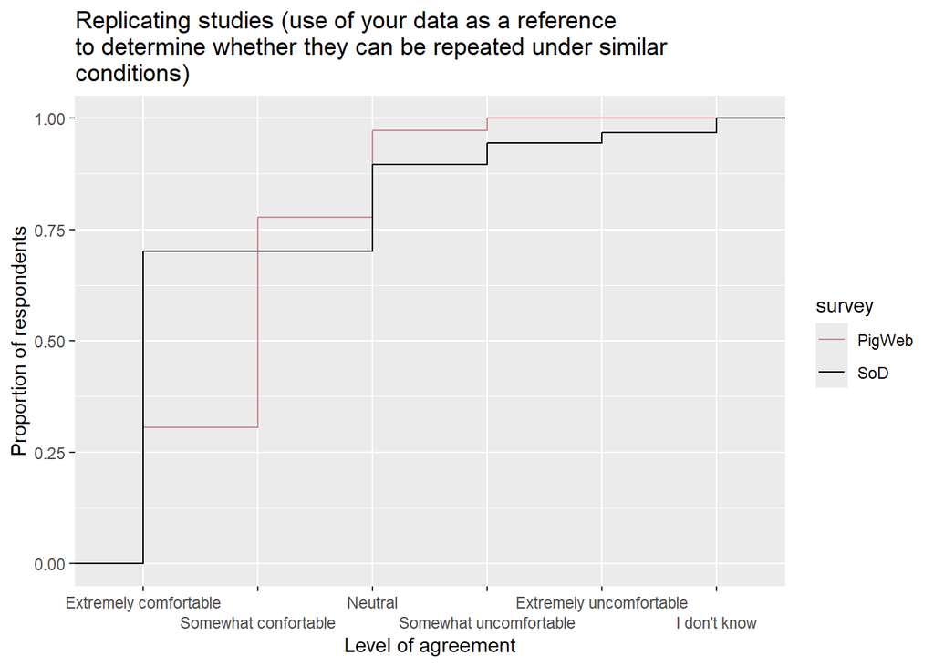

Figure 16

```r
#Creating data sets for Q16 (In otherwords: Isolating the responses of Q16 in the two surveys and adding this to a compiled data set, one for each survey)
sod21Q16 = as.data.frame(dplyr::select(sod21,60))
sod21Pile = cbind(sod21Pile, sod21Q16)
colnames(sod21Q16) = c('Q16')

pigw21Q16 = as.data.frame(dplyr::select(pigw21, 42))
pigw21Pile = cbind(pigw21Pile, pigw21Q16)


#Setting columnnames and storing the question for Q16
colnames(sod21Q16) = c('Q16')
colnames(pigw21Q16) = c('Q16')
Q16 = 'Replicating studies (use of your data as a reference to determine whether they can be repeated under similar conditions)'

#Setting the answer options to Q16.
Q16_levels = c("Extremely comfortable", "Somewhat confortable",
              "Neutral", "Somewhat uncomfortable",
              "Extremely uncomfortable", "I don't know")

#The Pigweb scale is correctly formatted for this question (Q16), thus no need to reverse the question.
#pigw21Q16$Q16 = reverseCode(pigw21Q16$Q16)

Q16_data = format_question_likert(sod21Q16$Q16, #Making the answers to Q16 in the two questionnaires comparable, merging them to one data frame
                                 pigw21Q16$Q16,
                                 Q16_levels)

plot_likert(Q16_data,  #Plotting the Level of agreement between the two surveys
            Q16_levels,
            Q16,
            "Level of agreement")
```

```r
#This section test for if there is statistically significant difference in the respondent groups¨
#with the null hyptohesis that the two populations are the same.

SvPQ16 = ks.test(Q16_data$response[Q16_data$survey == "SoD"],
        Q16_data$response[Q16_data$survey == "PigWeb"],
        ifresult = FALSE) #Kolmogorov-Smirnov test for Q16
```

# Question 17

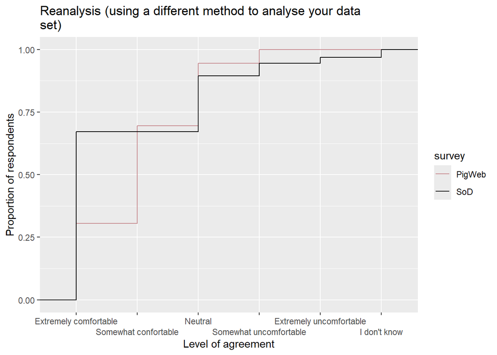

Figure 17

```r
#Creating data sets for Q17
sod21Q17 = as.data.frame(dplyr::select(sod21,61))
sod21Pile = cbind(sod21Pile, sod21Q17)
colnames(sod21Q17) = c('Q17')

pigw21Q17 = as.data.frame(dplyr::select(pigw21, 43))
pigw21Pile = cbind(pigw21Pile, pigw21Q17)


#Setting columnnames and storing the question for Q17
colnames(sod21Q17) = c('Q17')
colnames(pigw21Q17) = c('Q17')
Q17 = 'Reanalysis (using a different method to analyse your data set)'

#Setting the answer options to Q17.
Q17_levels = c("Extremely comfortable", "Somewhat confortable",
              "Neutral", "Somewhat uncomfortable",
              "Extremely uncomfortable", "I don't know")

#The Pigweb scale is correctly formatted for this question (Q17), thus no need to reverse the question.
#pigw21Q16$Q16 = reverseCode(pigw21Q17$Q17)


Q17_data = format_question_likert(sod21Q17$Q17, #Making the answers to Q17 in the two questionnaires comparable, merging them to one data frame
                                 pigw21Q17$Q17,
                                 Q17_levels)

plot_likert(Q17_data, #Plotting the Level of agreement between the two surveys
            Q17_levels,
            Q17,
            "Level of agreement")
```

```r
#This section test for if there is statistically significant difference in the respondent groups¨
#with the null hyptohesis that the two populations are the same.

SvPQ17 = ks.test(Q17_data$response[Q17_data$survey == "SoD"],
        Q17_data$response[Q17_data$survey == "PigWeb"],
        ifresult = FALSE) #Kolmogorov-Smirnov test for Q17
```

# Question 18

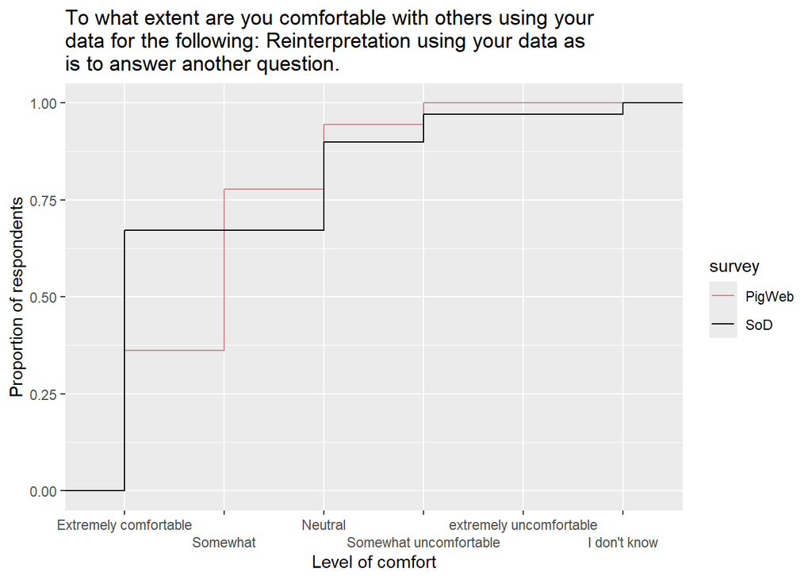

Figure Q18

```r
#Question 18
#To what extent are you comfortable with others using your data for the following
pigw21Q18 = as.data.frame(dplyr::select(pigw21, 44))
pigw21Pile = cbind(pigw21Pile, pigw21Q18)

#Setting column names and storing the question
colnames(pigw21Q18) = c('Q18')
Q18 = 'To what extent are you comfortable with others using your data for the following: Reinterpretation using your data as is to answer another question.'

#Setting the answer options to Question Q18.
Q18_levels = c("Extremely comfortable", "Somewhat", "Neutral", "Somewhat uncomfortable", "extremely uncomfortable", "I don't know")

sod21P1 = as.data.frame(dplyr::select(sod21,62))
sod21Pile = cbind(sod21Pile, sod21P1)
colnames(sod21P1) = c('Q18')

#The Pigweb scale puts strong agreement as 1 and strong disagreement as 5, this needs to be reversed for the question.
#pigw21Q18$Q18 = reverseCode(pigw21Q18$Q18)

Q18_data = format_question_likert(sod21P1$Q18,
                                 pigw21Q18$Q18,
                                 Q18_levels)

#Likert plot
plot_likert(Q18_data,
            Q18_levels,
            Q18,
            "Level of comfort")
```

```r
#This section test for if there is statistically significant difference in the respondent groups
#with the null hypothesis that the two populations are the same.

ks.test(Q18_data$response[Q18_data$survey == "SoD"],
        Q18_data$response[Q18_data$survey == "PigWeb"],
        ifresult = FALSE) #Kolmogorov-Smirnov test for Q18

#check number of NA's
sum(is.na(Q18_data$response))
```

[output not shown]

# Question 19

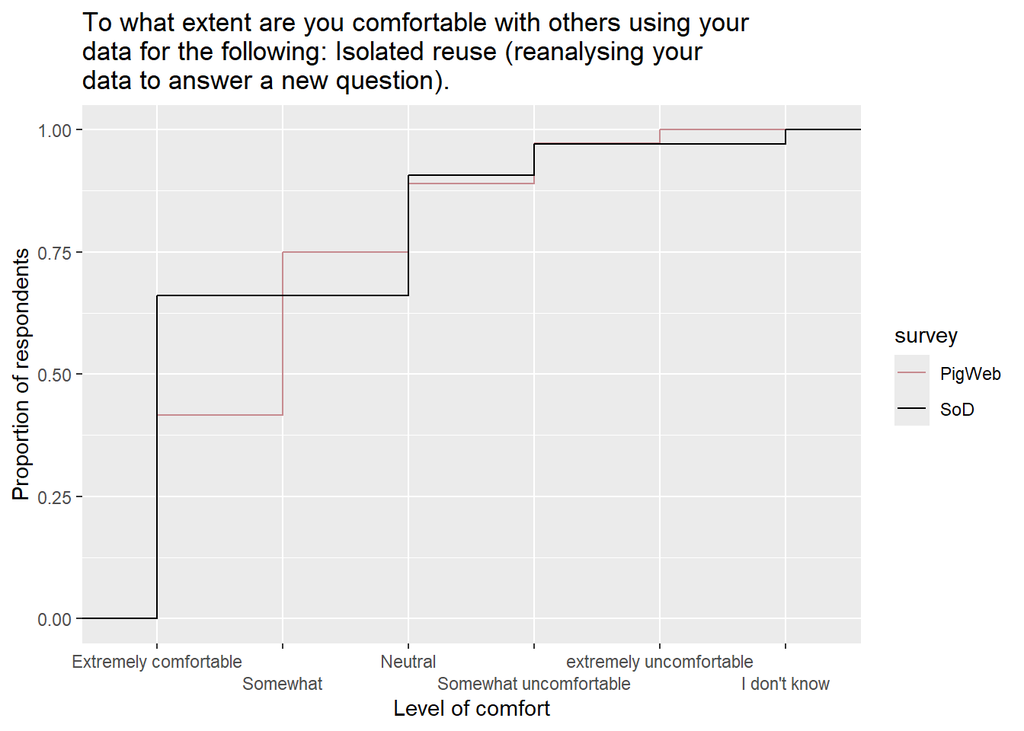

Figure Q19

```r
#Paulina question 2
#To what extent are you comfortable with others using your data for the following
pigw21Q19 = as.data.frame(dplyr::select(pigw21, 45))
pigw21Pile = cbind(pigw21Pile, pigw21Q19)

#Setting column names and storing the question
colnames(pigw21Q19) = c('Q19')
Q19 = 'To what extent are you comfortable with others using your data for the following: Isolated reuse (reanalysing your data to answer a new question).'

#Setting the answer options to Question Q19.
Q19_levels = c("Extremely comfortable", "Somewhat", "Neutral", "Somewhat uncomfortable", "extremely uncomfortable", "I don't know")

sod21Q19 = as.data.frame(dplyr::select(sod21,63))
sod21Pile = cbind(sod21Pile, sod21Q19)
colnames(sod21Q19) = c('Q19')

#The Pigweb scale puts strong agreement as 1 and strong disagreement as 5, this needs to be reversed for the question. This is not necessary here!
#pigw21Q19$Q19 = reverseCode(pigw21Q19$Q19)


Q19_data = format_question_likert(sod21Q19$Q19,
                                 pigw21Q19$Q19,
                                 Q19_levels)

#Likert plot
plot_likert(Q19_data,
            Q19_levels,
            Q19,
            "Level of comfort")
```

```r
#This section test for if there is statistically significant difference in the respondent groups
#with the null hypothesis that the two populations are the same.

ks.test(Q19_data$response[Q19_data$survey == "SoD"],
        Q19_data$response[Q19_data$survey == "PigWeb"],
        ifresult = FALSE) #Kolmogorov-Smirnov test for Q19
```

[output not shown]

# Question 20

To what extent are you comfortable with others using your data for the following:

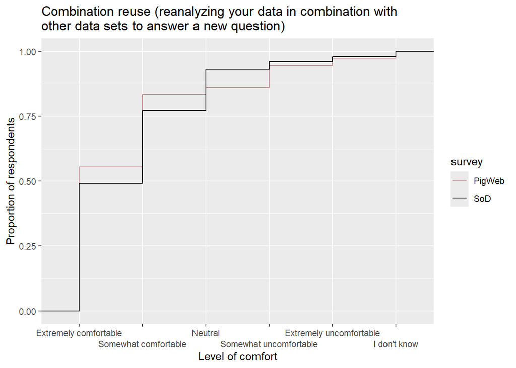

Figure 20

```r
# This is a single choice question measure on a likert scale
# - This code chunk uses likert functions

# Create data frames of answers from both surveys
# - i.e. extracting the column of the respective data frame that contains the answers
sod21Q20 <- as.data.frame(sod21[,64])
pigw21Q20 <- as.data.frame(pigw21[,46])

# Add the questions to the 'pile' with all the other questions
pigw21Pile <- cbind(pigw21Pile, pigw21Q20)
sod21Pile <- cbind(sod21Pile, sod21Q20)

#Setting column names
colnames(sod21Q20) = c('Q20')
colnames(pigw21Q20) = c('Q20')

# Storing the question (used for plotting)
# - The plot title
Q20 = 'Combination reuse (reanalyzing your data in combination with other data sets to answer a new question)'

# Setting the answer options to Question 20
# - i.e. the ticks on the x axis when plotting
Q20_levels = c("Extremely comfortable", "Somewhat comfortable",
              "Neutral", "Somewhat uncomfortable",
              "Extremely uncomfortable", "I don't know")

# The code below is used when it is necessary to reverse the question scale. This is not necessary here!
# pigw21Q20$Q20 = reverseCode(pigw21Q20$Q20)

# Create a data frame for plotting that combines SoD and PigWeb data for likert scale question
# - sod_data and pigweb_data are vectors of answers
# - levels is a vector of the levels in order from low to high
# NB! sod_data must be before pigweb_data
Q20_data <- format_question_likert(sod21Q20$Q20,
                                 pigw21Q20$Q20,
                                 Q20_levels)


# Plot a cumulative step graph of the answers for a Likert-scale question
# Arguments (in order):
# - A data frame produced by format_question_likert
# - A vector of levels in order from low to high
# - A character string of the question which will be the title
# - A character string for the x-axis label (not a separate vector, write text below)
plot_likert(Q20_data,
            Q20_levels,
            Q20,
            "Level of comfort")
```

# Question 21

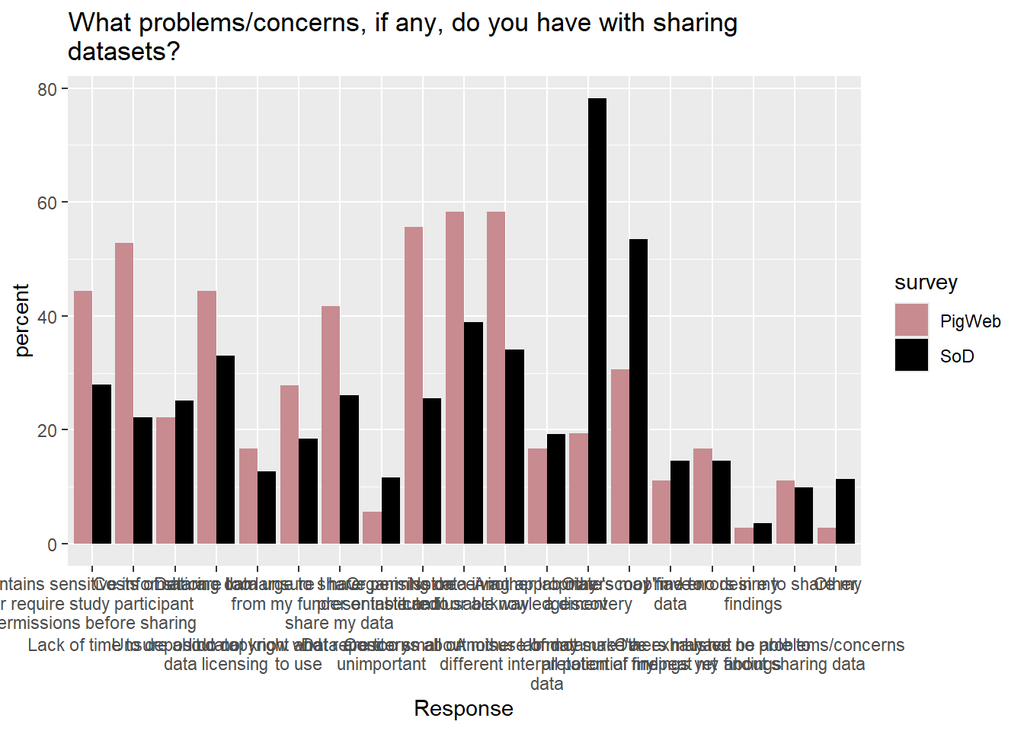

Figure 21

```r
#This code chunk uses the multiple choice functions.

#Response levels of Q21
Q21_levels = c("Contains sensitive information or require study participant permissions before sharing",
              "Lack of time to deposit data",
              "Costs of sharing data",
              "Unsure about copyright and data licensing",
              "Data are too large to share",
              "I do not know what repository to use",
              "I am unsure I have permission from my funder or institute to share my data",
              "Data are too small or unimportant",
              "Organising data in a presentable and usable way",
              "Concerns about misuse of data",
              "Not receiving appropriate credit or acknowledgement",
              "Another lab may make a different interpretation of my data",
              "Another lab may 'scoop' me to a discovery",
              "I'm not sure I've exhausted all potential findings yet",
              "Others may find errors in my data",
              "Others may not be able to repeat my findings",
              "I have no desire to share my findings",
              "I have no problems/concerns about sharing data",
              "Other")

n_columns = length(Q21_levels) #Calculating number of columns with answers to question 21 (One for each level of Q21 above)

sod21Q21 = as.data.frame(dplyr::select(sod21, (65:sum(65,n_columns,-1)))) #Summarizing the responses for all levels of Q21, except the "Other" category into one new data set
sod21Pile = cbind(sod21Pile, sod21Q21) #Adding these to the Pile

pigw21Q21 = as.data.frame(dplyr::select(pigw21, (47:sum(47,n_columns,-1)))) #Summarizing the responses for all levels of Q21, except the "Other" category into one new data set
pigw21Pile = cbind(pigw21Pile, pigw21Q21) #Adding these to the Pile

Q21 = "What problems/concerns, if any, do you have with sharing datasets?" #Question 21 and title of Figure 21

Q21_data = format_question_multiple_choice(sod21Q21,   #Making the answers to Q21 in the two questionnaires comparable, merging them to one data frame
                                          pigw21Q21,
                                          Q21_levels)

plot_multiple_choice(Q21_data,     #Plotting the responses without the "Other" option
                     Q21_levels,
                     Q21,
                     "Response")
```

```r
## Others responses for Q21
#unique(pigw21[,65])       #Changed to comment to avoid long list with all of the different answers
#unique(sod21[,84])        #Changed to comment to avoid long list with all of the different answers

sod21Q21other = as.data.frame(dplyr::select(sod21, 1))
sod21Pile = cbind(sod21Pile, sod21Q21other)


pigw21Q21other = as.data.frame(dplyr::select(pigw21, 1))
pigw21Pile = cbind(pigw21Pile, pigw21Q21other)
```